# SCC

Evangelina

2023-07-19

```
## [conflicted] Will prefer dplyr::select over any other package.
## [conflicted] Will prefer dplyr::filter over any other package.
```

# Somatic count cells

Data summary

| Name | Piped data |
| --- | --- |
| Number of rows | 74 |
| Number of columns | 13 |
| _______________________ |  |
| Column type frequency: |  |
| numeric | 13 |
| ________________________ |  |
| Group variables | None |

**Variable type: numeric**

| skim_variable | n_missing | complete_rate | mean | sd | p0 | p25 | p50 | p75 | p100 | hist |
| --- | --- | --- | --- | --- | --- | --- | --- | --- | --- | --- |
| vacination | 0 | 1 | 2.51 | 0.60 | 1 | 2.00 | 3.0 | 3 | 3.0 | ▁▁▅▁▇ |
| prepartum | 0 | 1 | 2.38 | 0.63 | 1 | 2.00 | 2.0 | 3 | 3.0 | ▂▁▇▁▇ |
| experience | 0 | 1 | 3.14 | 1.04 | 1 | 2.00 | 4.0 | 4 | 4.0 | ▁▃▁▂▇ |
| capacitations | 0 | 1 | 1.59 | 0.76 | 1 | 1.00 | 1.0 | 2 | 3.0 | ▇▁▃▁▂ |
| rearing_system | 0 | 1 | 1.84 | 0.47 | 1 | 2.00 | 2.0 | 2 | 2.5 | ▂▁▁▇▂ |
| realiza_calostrado | 0 | 1 | 1.86 | 0.69 | 1 | 1.00 | 2.0 | 2 | 3.0 | ▅▁▇▁▃ |
| calostrum_feeding_num | 0 | 1 | 1.57 | 0.64 | 1 | 1.00 | 1.0 | 2 | 3.0 | ▇▁▆▁▁ |
| clostrum_feeding_vol | 0 | 1 | 3.32 | 1.15 | 1 | 2.25 | 3.5 | 4 | 5.0 | ▂▅▆▇▃ |
| liquid_feeding_volume | 0 | 1 | 2.38 | 0.52 | 1 | 2.00 | 2.0 | 3 | 3.0 | ▁▁▇▁▅ |
| hygiene | 0 | 1 | 2.28 | 0.73 | 1 | 2.00 | 2.0 | 3 | 3.0 | ▃▁▇▁▇ |
| mortality | 0 | 1 | 5.80 | 4.66 | 2 | 2.00 | 4.5 | 7 | 15.0 | ▇▆▁▁▂ |
| feed_cows | 0 | 1 | 2.30 | 0.46 | 2 | 2.00 | 2.0 | 3 | 3.0 | ▇▁▁▁▃ |
| scc | 0 | 1 | 325.70 | 105.05 | 80 | 265.00 | 302.5 | 369 | 633.0 | ▂▇▇▂▁ |

```
## Anova Table (Type II tests)
##
## Response: scc
##                      Sum Sq Df F value   Pr(>F)
## capacitations          2201  1  0.2154 0.644109
## mortality              2201  1  0.2154 0.644076
## hygiene               72627  1  7.1070 0.009614 **
## clostrum_feeding_vol    918  1  0.0898 0.765308
## vacination             2869  1  0.2807 0.597985
## feed_cows               403  1  0.0394 0.843172
## Residuals            684678 67
## ---
## Signif. codes:  0 '***' 0.001 '**' 0.01 '*' 0.05 '.' 0.1 ' ' 1
```

## Regresion lineal multiple

```
##
## Call:
## lm(formula = scc ~ ., data = na.omit(dat_scc))
##
## Residuals:
##      Min       1Q   Median       3Q      Max
## -195.573  -60.906   -0.646   44.086  243.833
##
## Coefficients:
##                       Estimate Std. Error t value Pr(>|t|)
## (Intercept)           522.8059   138.4537   3.776 0.000364 ***
## vacination             -0.9602    23.5497  -0.041 0.967608
## prepartum             -17.7327    21.3209  -0.832 0.408822
## experience            -22.0700    13.4790  -1.637 0.106703
## capacitations         -14.4902    20.6271  -0.702 0.485050
## rearing_system         22.3714    26.6599   0.839 0.404667
## realiza_calostrado     27.1553    19.4648   1.395 0.168045
## calostrum_feeding_num  -3.3647    25.4518  -0.132 0.895263
## clostrum_feeding_vol    2.4375    15.2353   0.160 0.873418
## liquid_feeding_volume   2.1980    28.3294   0.078 0.938411
## hygiene               -50.4624    18.2339  -2.768 0.007468 **
## mortality              -0.5656     3.1300  -0.181 0.857193
## feed_cows             -18.1322    31.8805  -0.569 0.571610
## ---
## Signif. codes:  0 '***' 0.001 '**' 0.01 '*' 0.05 '.' 0.1 ' ' 1
##
## Residual standard error: 100.5 on 61 degrees of freedom
## Multiple R-squared:  0.235,  Adjusted R-squared:  0.08445
## F-statistic: 1.561 on 12 and 61 DF,  p-value: 0.1276
```

```
## Start:  AIC=694.03
## scc ~ vacination + prepartum + experience + capacitations + rearing_system +
##     realiza_calostrado + calostrum_feeding_num + clostrum_feeding_vol +
##     liquid_feeding_volume + hygiene + mortality + feed_cows
##
##                         Df Sum of Sq    RSS    AIC
## - vacination             1        17 616339 692.03
## - liquid_feeding_volume  1        61 616383 692.04
## - calostrum_feeding_num  1       177 616499 692.05
## - clostrum_feeding_vol   1       259 616581 692.06
## - mortality              1       330 616652 692.07
## - feed_cows              1      3268 619591 692.42
## - capacitations          1      4986 621308 692.63
## - prepartum              1      6989 623311 692.87
## - rearing_system         1      7115 623437 692.88
## <none>                               616322 694.03
## - realiza_calostrado     1     19665 635987 694.36
## - experience             1     27088 643410 695.21
## - hygiene                1     77385 693707 700.78
##
## Step:  AIC=692.03
## scc ~ prepartum + experience + capacitations + rearing_system +
##     realiza_calostrado + calostrum_feeding_num + clostrum_feeding_vol +
##     liquid_feeding_volume + hygiene + mortality + feed_cows
##
##                         Df Sum of Sq    RSS    AIC
## - liquid_feeding_volume  1        53 616392 690.04
## - calostrum_feeding_num  1       170 616509 690.05
## - clostrum_feeding_vol   1       252 616591 690.06
## - mortality              1       396 616735 690.08
## - feed_cows              1      3392 619731 690.44
## - capacitations          1      5530 621869 690.70
## - prepartum              1      6977 623316 690.87
## - rearing_system         1      7113 623452 690.88
## <none>                               616339 692.03
## - realiza_calostrado     1     20242 636581 692.43
## - experience             1     27141 643480 693.22
## + vacination             1        17 616322 694.03
## - hygiene                1     77369 693708 698.78
##
```

[output cut: 154 more lines]

```
##
##                         Df Sum of Sq    RSS    AIC
## <none>                               661370 679.25
## + realiza_calostrado     1     16461 644909 679.39
## + prepartum              1      6683 654687 680.50
## + capacitations          1      6201 655169 680.56
## + rearing_system         1      5540 655831 680.63
## + feed_cows              1      2222 659149 681.00
## + liquid_feeding_volume  1      1425 659946 681.09
## - experience             1     35559 696930 681.13
## + calostrum_feeding_num  1       289 661082 681.22
## + mortality              1       113 661258 681.24
## + clostrum_feeding_vol   1        37 661334 681.25
## + vacination             1        15 661355 681.25
## - hygiene                1    120885 782256 689.67
```

```
##
## Call:
## lm(formula = scc ~ experience + hygiene, data = na.omit(dat_scc))
##
## Residuals:
##      Min       1Q   Median       3Q      Max
## -219.046  -65.854   -9.472   39.331  245.763
##
## Coefficients:
##             Estimate Std. Error t value Pr(>|t|)
## (Intercept)   520.53      53.08   9.806 7.76e-15 ***
## experience    -21.38      10.94  -1.954 0.054663 .
## hygiene       -55.96      15.53  -3.602 0.000581 ***
## ---
## Signif. codes:  0 '***' 0.001 '**' 0.01 '*' 0.05 '.' 0.1 ' ' 1
##
## Residual standard error: 96.51 on 71 degrees of freedom
## Multiple R-squared:  0.179,  Adjusted R-squared:  0.1559
## F-statistic: 7.742 on 2 and 71 DF,  p-value: 0.0009089
```

Como se puede ver tanto en el modelo manual como en el que el mismo r arroja, el conteo de celulas somaticas se ve afectado por las practicas de higiene y hay una tendencia de la experiencia del personal en el preparto.

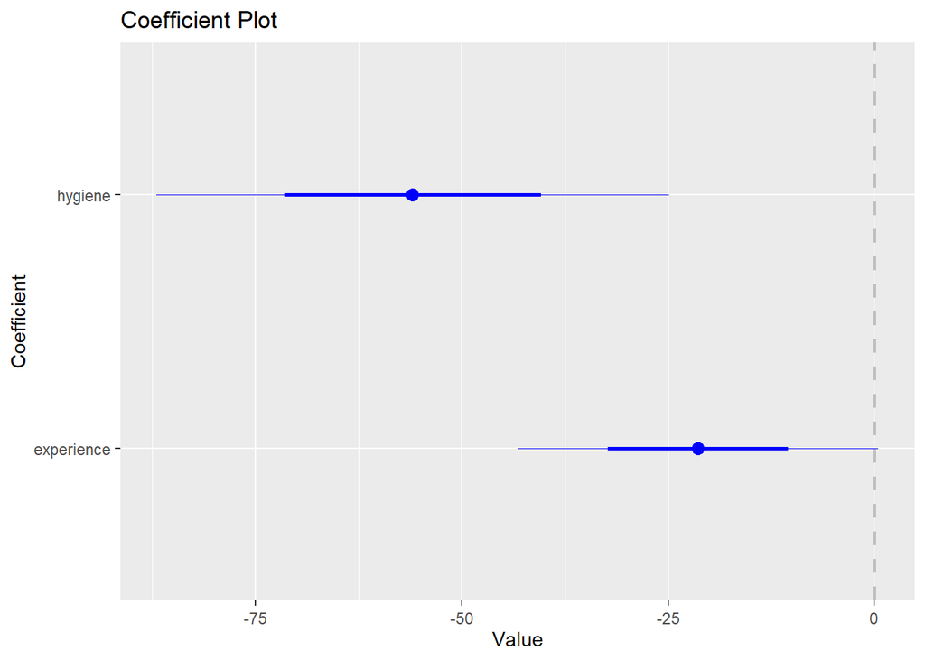

En este grafico podemos ver que ambas variables, higiene y experiencia del personal, disminuyen el conteo de celulas somaticas.

Analizo la importancia relativa de las variables presentes en el modelo

```
## Response variable: scc
## Total response variance: 11035.64
## Analysis based on 74 observations
##
## 2 Regressors:
## experience hygiene
## Proportion of variance explained by model: 17.9%
## Metrics are normalized to sum to 100% (rela=TRUE).
##
## Relative importance metrics:
##
##                  car
## experience 0.2025484
## hygiene    0.7974516
```

## Arbol de clasificacion

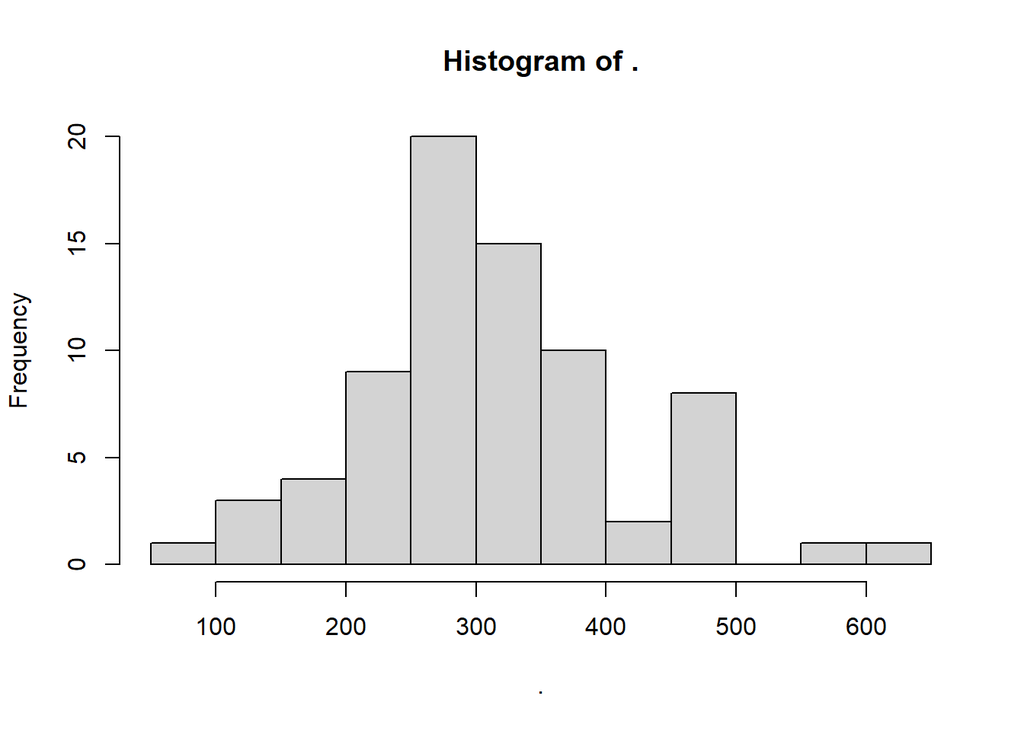

```
## 'data.frame':    74 obs. of  13 variables:
##  $ vacination           : int  1 2 3 3 2 2 2 3 3 3 ...
##  $ prepartum            : int  3 3 3 2 1 1 3 3 1 2 ...
##  $ experience           : int  4 3 4 2 2 4 4 4 3 4 ...
##  $ capacitations        : int  1 1 2 1 2 1 1 1 1 1 ...
##  $ rearing_system       : num  2 2 2 1 2 1 2.5 2 1 2 ...
##  $ realiza_calostrado   : int  1 2 3 1 1 2 1 2 2 2 ...
##  $ calostrum_feeding_num: int  2 1 3 2 2 1 1 2 2 1 ...
##  $ clostrum_feeding_vol : int  5 3 5 3 2 4 1 4 3 3 ...
##  $ liquid_feeding_volume: int  2 3 3 2 2 3 3 3 3 3 ...
##  $ hygiene              : int  2 3 2 3 3 2 2 2 1 2 ...
##  $ mortality            : int  2 7 2 15 2 2 2 15 7 2 ...
##  $ feed_cows            : int  2 2 2 2 2 2 2 2 2 2 ...
##  $ scc                  : logi  TRUE TRUE FALSE TRUE TRUE TRUE ...
```

```
##    rowid vacination prepartum experience capacitations rearing_system
## 1      1          1         3          4             1            2.0
## 2      2          2         3          3             1            2.0
## 3      3          3         3          4             2            2.0
## 4      4          3         2          2             1            1.0
## 5      5          2         1          2             2            2.0
## 6      6          2         1          4             1            1.0
## 7      7          2         3          4             1            2.5
## 8      8          3         3          4             1            2.0
## 9      9          3         1          3             1            1.0
## 10    10          3         2          4             1            2.0
## 11    11          3         2          4             1            2.0
## 12    12          2         3          4             1            2.0
## 13    13          3         2          4             1            2.0
## 14    14          3         2          3             1            2.0
```

[output cut: 210 more lines]

```
## n= 74
##
## node), split, n, deviance, yval
##       * denotes terminal node
##
##  1) root 74 10.0540500 0.8378378
##    2) hygiene>=2.5 33  6.5454550 0.7272727
##      4) capacitations< 1.5 14  3.4285710 0.5714286 *
##      5) capacitations>=1.5 19  2.5263160 0.8421053 *
##    3) hygiene< 2.5 41  2.7804880 0.9268293
##      6) experience>=3.5 25  2.6400000 0.8800000
##       12) calostrum_feeding_num< 1.5 10  1.6000000 0.8000000 *
##       13) calostrum_feeding_num>=1.5 15  0.9333333 0.9333333 *
##      7) experience< 3.5 16  0.0000000 1.0000000 *
```

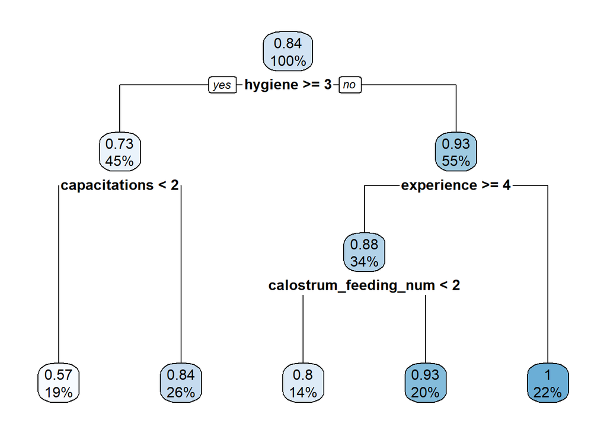

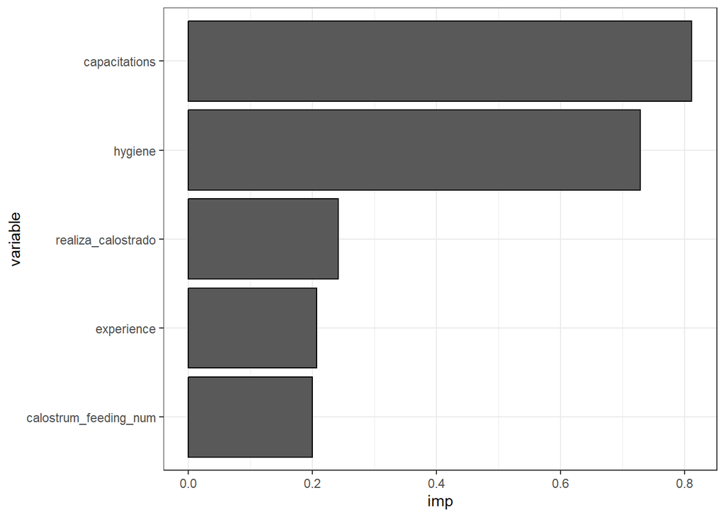

## Regresion logistica

```
##
## Call:
## glm(formula = SCC ~ hygiene + calostrum_feeding_num + realiza_calostrado +
##     capacitations + vacination + experience, family = binomial,
##     data = dat_scc)
##
## Coefficients:
##                         Estimate Std. Error z value Pr(>|z|)
## (Intercept)           -2.657e+01  3.135e+05       0        1
## hygiene               -2.887e-15  6.075e+04       0        1
## calostrum_feeding_num  7.101e-16  6.713e+04       0        1
## realiza_calostrado    -6.776e-15  6.631e+04       0        1
## capacitations          3.502e-15  6.362e+04       0        1
## vacination            -1.306e-14  7.968e+04       0        1
## experience             4.624e-15  4.218e+04       0        1
##
## (Dispersion parameter for binomial family taken to be 1)
##
##     Null deviance: 0.0000e+00  on 73  degrees of freedom
## Residual deviance: 4.2932e-10  on 67  degrees of freedom
## AIC: 14
##
## Number of Fisher Scoring iterations: 25
```

|  | SCC |  |  |
| --- | --- | --- | --- |
| Predictors | Odds Ratios | CI | p |
| (Intercept) | 0.00 | 0.00 – Inf | 1.000 |
| hygiene | 1.00 | 0.00 – Inf | 1.000 |
| calostrum feeding num | 1.00 | 0.00 – Inf | 1.000 |
| realiza calostrado | 1.00 | 0.00 – Inf | 1.000 |
| capacitations | 1.00 | 0.00 – Inf | 1.000 |
| vacination | 1.00 | 0.00 – Inf | 1.000 |
| experience | 1.00 | 0.00 – Inf | 1.000 |
| Observations | 74 |  |  |

No hay odds de nada

## Factorizo variables predictoras

Si factorizo las variables predictoras, el modelo queda de la siguiente forma:

```
##    vacination prepartum experience capacitations rearing_system
## 1           1         3          4             1              2
## 2           2         3          3             1              2
## 3           3         3          4             2              2
## 4           3         2          2             1              1
## 5           2         1          2             2              2
## 6           2         1          4             1              1
## 7           2         3          4             1            2.5
## 8           3         3          4             1              2
## 9           3         1          3             1              1
## 10          3         2          4             1              2
## 11          3         2          4             1              2
## 12          2         3          4             1              2
## 13          3         2          4             1              2
## 14          3         2          3             1              2
```

[output cut: 210 more lines]

## Reg. lineal múltiple

```
## Analysis of Variance Table
##
## Response: scc
##                       Df Sum Sq Mean Sq F value  Pr(>F)
## vacination             2  21170   10585  1.2012 0.30990
## prepartum              2  64089   32044  3.6364 0.03401 *
## experience             3  56677   18892  2.1439 0.10727
## capacitations          2  47955   23978  2.7210 0.07618 .
## rearing_system         2  28329   14164  1.6074 0.21123
## realiza_calostrado     2  12088    6044  0.6859 0.50863
## calostrum_feeding_num  2  59044   29522  3.3502 0.04364 *
## clostrum_feeding_vol   4  15066    3766  0.4274 0.78807
## liquid_feeding_volume  2   7493    3746  0.4251 0.65617
## hygiene                2  59516   29758  3.3770 0.04262 *
## mortality              2    961     480  0.0545 0.94702
## feed_cows              1  19047   19047  2.1614 0.14818
## Residuals             47 414169    8812
## ---
## Signif. codes:  0 '***' 0.001 '**' 0.01 '*' 0.05 '.' 0.1 ' ' 1
```

```
## Start:  AIC=692.62
## scc ~ vacination + prepartum + experience + capacitations + rearing_system +
##     realiza_calostrado + calostrum_feeding_num + clostrum_feeding_vol +
##     liquid_feeding_volume + hygiene + mortality + feed_cows
##
##                         Df Sum of Sq    RSS    AIC
## - clostrum_feeding_vol   4     16385 430554 687.49
## - mortality              2      1315 415484 688.85
## - liquid_feeding_volume  2      3226 417394 689.19
## - capacitations          2      5090 419259 689.52
## - realiza_calostrado     2     17554 431723 691.69
## <none>                               414169 692.62
## - rearing_system         2     27388 441556 693.36
## - feed_cows              1     19047 433215 693.94
## - experience             3     47608 461776 694.67
## - calostrum_feeding_num  2     36660 450828 694.89
## - prepartum              2     53038 467206 697.53
## - hygiene                2     63313 477482 699.14
## - vacination             2     96302 510471 704.09
##
## Step:  AIC=687.49
## scc ~ vacination + prepartum + experience + capacitations + rearing_system +
##     realiza_calostrado + calostrum_feeding_num + liquid_feeding_volume +
##     hygiene + mortality + feed_cows
##
##                         Df Sum of Sq    RSS    AIC
## - mortality              2      2229 432782 683.87
## - liquid_feeding_volume  2      3499 434052 684.09
## - capacitations          2      4142 434695 684.20
## - realiza_calostrado     2      9513 440066 685.11
## - rearing_system         2     20261 450815 686.89
## <none>                               430554 687.49
## - feed_cows              1     14957 445510 688.02
## - experience             3     40939 471493 688.21
## - prepartum              2     44500 475054 690.77
## - calostrum_feeding_num  2     50092 480646 691.63
## + clostrum_feeding_vol   4     16385 414169 692.62
## - hygiene                2     66530 497084 694.12
## - vacination             2     93321 523875 698.01
##
```

[output cut: 61 more lines]

```
##
##                         Df Sum of Sq    RSS    AIC
## <none>                               451992 675.08
## - feed_cows              1     14248 466240 675.38
## - rearing_system         2     31366 483357 676.05
## + realiza_calostrado     2     11191 440801 677.23
## - experience             3     53232 505223 677.32
## + capacitations          2      5360 446631 678.20
## + liquid_feeding_volume  2      4459 447533 678.35
## + mortality              2      2320 449672 678.70
## - prepartum              2     53469 505461 679.36
## - calostrum_feeding_num  2     56090 508082 679.74
## + clostrum_feeding_vol   4      6675 445317 681.98
## - vacination             2     84317 536309 683.74
## - hygiene                2     98044 550035 685.61
```

```
## Analysis of Variance Table
##
## Response: scc
##                       Df Sum Sq Mean Sq F value   Pr(>F)
## vacination             2  21170   10585  1.3817 0.259159
## prepartum              2  64089   32044  4.1828 0.020007 *
## experience             3  56677   18892  2.4661 0.071012 .
## rearing_system         2  46707   23354  3.0484 0.054968 .
## calostrum_feeding_num  2  46738   23369  3.0504 0.054870 .
## hygiene                2 103981   51990  6.7865 0.002225 **
## feed_cows              1  14248   14248  1.8599 0.177817
## Residuals             59 451992    7661
## ---
## Signif. codes:  0 '***' 0.001 '**' 0.01 '*' 0.05 '.' 0.1 ' ' 1
```

Se puede ver que en el modelo las variables preparto e higiene afectan las ccs, mientras que elnumero de tomas de calostro, sistema de alojamiento de terneros y la experiencia del personal tienen una tendencia a impactar en las ccs

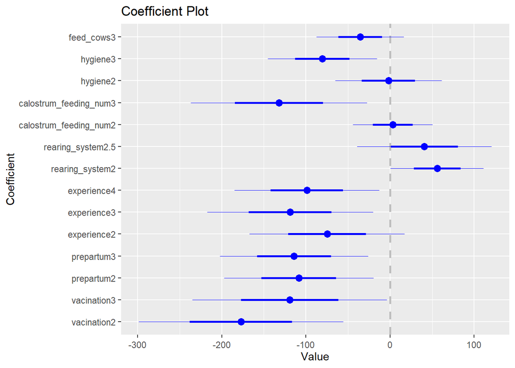

```
## Start:  AIC=904.62
## scc ~ vacination + prepartum + experience + capacitations + rearing_system +
##     realiza_calostrado + calostrum_feeding_num + clostrum_feeding_vol +
##     liquid_feeding_volume + hygiene + mortality + feed_cows
##
##                         Df Deviance    AIC
## - clostrum_feeding_vol   4   430554 899.49
## - mortality              2   415484 900.85
## - liquid_feeding_volume  2   417394 901.19
## - capacitations          2   419259 901.52
## - realiza_calostrado     2   431723 903.69
## <none>                       414169 904.62
## - rearing_system         2   441556 905.36
## - feed_cows              1   433215 905.95
## - experience             3   461776 906.67
## - calostrum_feeding_num  2   450828 906.90
## - prepartum              2   467206 909.54
## - hygiene                2   477482 911.15
## - vacination             2   510471 916.09
##
## Step:  AIC=899.49
## scc ~ vacination + prepartum + experience + capacitations + rearing_system +
##     realiza_calostrado + calostrum_feeding_num + liquid_feeding_volume +
##     hygiene + mortality + feed_cows
##
##                         Df Deviance    AIC
## - mortality              2   432782 895.87
## - liquid_feeding_volume  2   434052 896.09
## - capacitations          2   434695 896.20
## - realiza_calostrado     2   440066 897.11
## - rearing_system         2   450815 898.89
## <none>                       430554 899.49
## - feed_cows              1   445510 900.02
## - experience             3   471493 900.21
## - prepartum              2   475054 902.77
## - calostrum_feeding_num  2   480646 903.64
## + clostrum_feeding_vol   4   414169 904.62
## - hygiene                2   497084 906.12
## - vacination             2   523875 910.01
##
```

[output cut: 61 more lines]

```
##
##                         Df Deviance    AIC
## <none>                       451992 887.09
## - feed_cows              1   466240 887.38
## - rearing_system         2   483357 888.05
## + realiza_calostrado     2   440801 889.23
## - experience             3   505223 889.33
## + capacitations          2   446631 890.20
## + liquid_feeding_volume  2   447533 890.35
## + mortality              2   449672 890.71
## - prepartum              2   505461 891.36
## - calostrum_feeding_num  2   508082 891.74
## + clostrum_feeding_vol   4   445317 893.99
## - vacination             2   536309 895.74
## - hygiene                2   550035 897.61
```

```
## Analysis of Deviance Table (Type II tests)
##
## Response: scc
##                       LR Chisq Df Pr(>Chisq)
## vacination             11.0062  2   0.004074 **
## prepartum               6.9795  2   0.030509 *
## experience              6.9485  3   0.073558 .
## rearing_system          4.0943  2   0.129104
## calostrum_feeding_num   7.3217  2   0.025711 *
## hygiene                12.7980  2   0.001663 **
## feed_cows               1.8599  1   0.172636
## ---
## Signif. codes:  0 '***' 0.001 '**' 0.01 '*' 0.05 '.' 0.1 ' ' 1
```

```
##
## Call:
## glm(formula = scc ~ vacination + prepartum + experience + rearing_system +
##     calostrum_feeding_num + hygiene + feed_cows, data = scc_new)
##
## Coefficients:
##                        Estimate Std. Error t value Pr(>|t|)
## (Intercept)              665.01      82.69   8.042 4.65e-11 ***
## vacination2             -177.24      60.82  -2.914  0.00503 **
## vacination3             -119.05      57.87  -2.057  0.04410 *
## prepartum2              -108.39      44.47  -2.437  0.01782 *
## prepartum3              -114.06      44.01  -2.592  0.01201 *
## experience2              -74.80      46.09  -1.623  0.10995
## experience3             -118.72      49.32  -2.407  0.01921 *
## experience4              -98.77      43.04  -2.295  0.02533 *
## rearing_system2           56.01      27.74   2.019  0.04803 *
## rearing_system2.5         40.88      39.94   1.024  0.31016
## calostrum_feeding_num2     3.34      23.62   0.141  0.88801
## calostrum_feeding_num3  -131.98      52.38  -2.520  0.01447 *
## hygiene2                  -1.84      31.63  -0.058  0.95380
## hygiene3                 -80.49      32.45  -2.480  0.01599 *
## feed_cows3               -35.39      25.95  -1.364  0.17782
## ---
## Signif. codes:  0 '***' 0.001 '**' 0.01 '*' 0.05 '.' 0.1 ' ' 1
##
## (Dispersion parameter for gaussian family taken to be 7660.876)
##
##     Null deviance: 805601  on 73  degrees of freedom
## Residual deviance: 451992  on 59  degrees of freedom
## AIC: 887.09
##
## Number of Fisher Scoring iterations: 2
```

|  | scc |  |  |
| --- | --- | --- | --- |
| Predictors | Estimates | CI | p |
| (Intercept) | 665.01 | 502.93 – 827.09 | **<0.001** |
| vacination [2] | -177.23 | -296.44 – -58.03 | **0.004** |
| vacination [3] | -119.05 | -232.49 – -5.62 | **0.040** |
| prepartum [2] | -108.39 | -195.55 – -21.23 | **0.015** |
| prepartum [3] | -114.06 | -200.31 – -27.81 | **0.010** |
| experience [2] | -74.80 | -165.13 – 15.54 | 0.105 |
| experience [3] | -118.72 | -215.38 – -22.07 | **0.016** |
| experience [4] | -98.77 | -183.13 – -14.41 | **0.022** |
| rearing system [2] | 56.01 | 1.64 – 110.37 | **0.043** |
| rearing system [2.5] | 40.88 | -37.39 – 119.15 | 0.306 |
| calostrum feeding num [2] | 3.34 | -42.95 – 49.63 | 0.888 |
| calostrum feeding num [3] | -131.98 | -234.63 – -29.32 | **0.012** |
| hygiene [2] | -1.84 | -63.83 – 60.15 | 0.954 |
| hygiene [3] | -80.49 | -144.09 – -16.89 | **0.013** |
| feed cows [3] | -35.39 | -86.25 – 15.47 | 0.173 |
| Observations | 74 |  |  |
| R<sup>2</sup> | 0.439 |  |  |

```
## $odds_data
## # A tibble: 14 × 4
##          OR     lower    upper vars
##       <dbl>     <dbl>    <dbl> <chr>
##  1 1.07e-77 1.81e-129 6.28e-26 vacination2
##  2 1.97e-52 1.08e-101 3.61e- 3 vacination3
##  3 8.44e-48 1.19e- 85 6.00e-10 prepartum2
##  4 2.91e-50 1.02e- 87 8.35e-13 prepartum3
##  5 3.28e-33 1.92e- 72 5.59e+ 6 experience2
##  6 2.75e-52 2.89e- 94 2.61e-10 experience3
##  7 1.28e-43 2.94e- 80 5.53e- 7 experience4
##  8 2.10e+24 5.16e+  0 8.58e+47 rearing_system2
##  9 5.68e+17 5.77e- 17 5.59e+51 rearing_system2.5
## 10 2.82e+ 1 2.23e- 19 3.58e+21 calostrum_feeding_num2
## 11 4.82e-58 1.26e-102 1.84e-13 calostrum_feeding_num3
## 12 1.59e- 1 1.90e- 28 1.32e+26 hygiene2
## 13 1.10e-35 2.63e- 63 4.62e- 8 hygiene3
## 14 4.28e-16 3.50e- 38 5.23e+ 6 feed_cows3
##
## $odds_plot
```

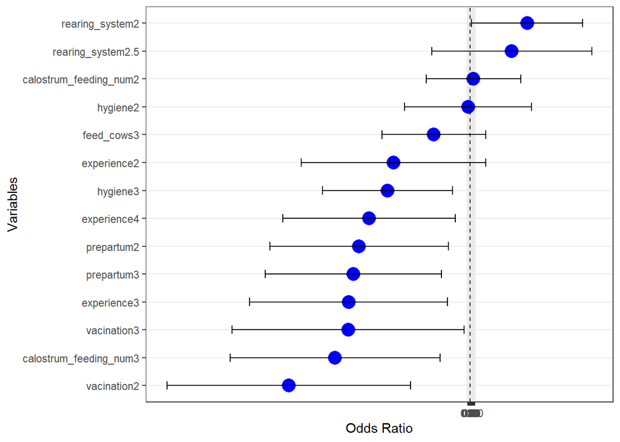

```
## n= 74
##
## node), split, n, deviance, yval
##       * denotes terminal node
##
##  1) root 74 805601.50 325.7027
##    2) hygiene=3 33 259810.10 276.5758
##      4) realiza_calostrado=1,3 11  77268.18 232.2727 *
##      5) realiza_calostrado=2 22 150156.40 298.7273
##       10) clostrum_feeding_vol=2,4 13  29393.23 270.4615 *
##       11) clostrum_feeding_vol=3,5 9  95374.22 339.5556 *
##    3) hygiene=1,2 41 402043.60 365.2439
##      6) realiza_calostrado=1,2 32 241507.20 352.6562
##       12) mortality=7,15 17  69404.94 323.9412 *
##       13) mortality=2 15 142198.40 385.2000 *
##      7) realiza_calostrado=3 9 137438.00 410.0000 *
```

```
## Call:
## rpart(formula = scc ~ ., data = scc_new)
##   n= 74
##
##           CP nsplit rel error    xerror      xstd
## 1 0.17843542      0 1.0000000 1.0173677 0.1897427
## 2 0.04020042      1 0.8215646 0.8635627 0.1634948
## 3 0.03289605      2 0.7813642 1.1558853 0.1937036
## 4 0.03151547      4 0.7155720 1.1667391 0.1944675
## 5 0.01000000      5 0.6840566 1.2075230 0.2087678
##
## Variable importance
##               hygiene    realiza_calostrado             mortality
##                    30                    17                    10
##         capacitations  clostrum_feeding_vol            experience
##                    10                     9                     7
##             prepartum        rearing_system liquid_feeding_volume
##                     6                     4                     2
## calostrum_feeding_num            vacination             feed_cows
##                     2                     1                     1
##
## Node number 1: 74 observations,    complexity param=0.1784354
##   mean=325.7027, MSE=10886.51
##   left son=2 (33 obs) right son=3 (41 obs)
##   Primary splits:
##       hygiene            splits as  RRL, improve=0.17843540, (0 missing)
##       capacitations      splits as  RRL, improve=0.03632703, (0 missing)
##       rearing_system     splits as  LRL, improve=0.03134752, (0 missing)
##       realiza_calostrado splits as  LLR, improve=0.02407191, (0 missing)
##       mortality          splits as  LRR, improve=0.02351535, (0 missing)
##   Surrogate splits:
##       capacitations      splits as  RRL,  agree=0.689, adj=0.303, (0 split)
##       realiza_calostrado splits as  RLR,  agree=0.635, adj=0.182, (0 split)
##       prepartum          splits as  RRL,  agree=0.608, adj=0.121, (0 split)
##       experience         splits as  RLRR, agree=0.608, adj=0.121, (0 split)
##       rearing_system     splits as  RRL,  agree=0.595, adj=0.091, (0 split)
##
## Node number 2: 33 observations,    complexity param=0.04020042
##   mean=276.5758, MSE=7873.032
##   left son=4 (11 obs) right son=5 (22 obs)
```

[output cut: 57 more lines]

```
##
## Node number 7: 9 observations
##   mean=410, MSE=15270.89
##
## Node number 10: 13 observations
##   mean=270.4615, MSE=2261.018
##
## Node number 11: 9 observations
##   mean=339.5556, MSE=10597.14
##
## Node number 12: 17 observations
##   mean=323.9412, MSE=4082.644
##
## Node number 13: 15 observations
##   mean=385.2, MSE=9479.893
```

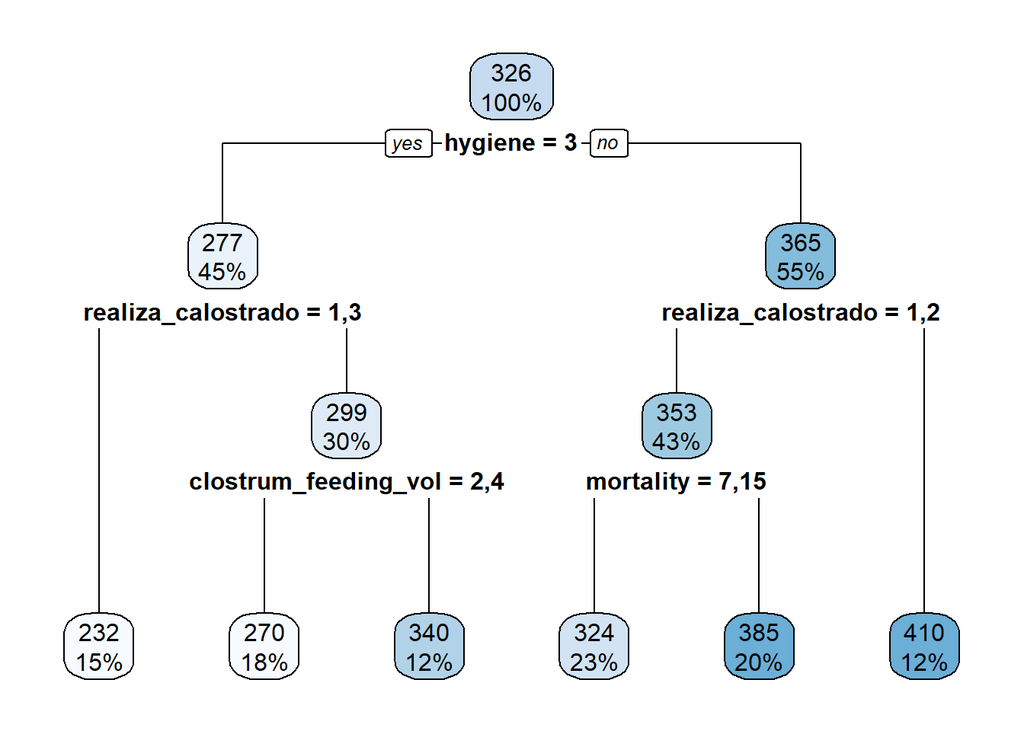

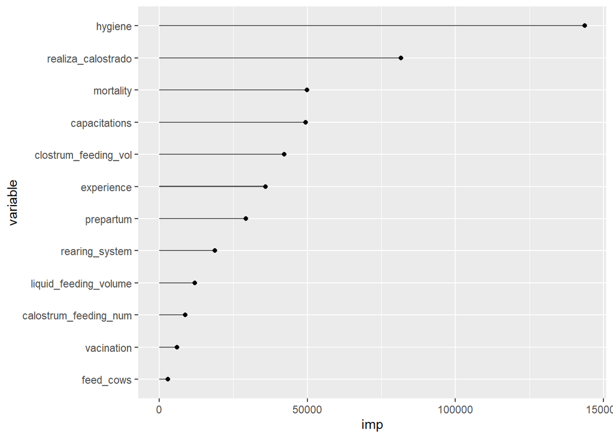

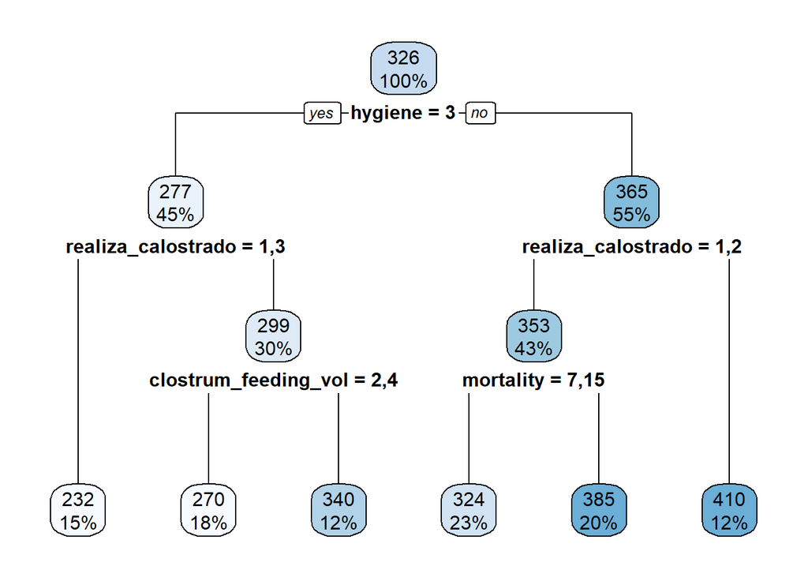

```
## scc is 232 when
##     hygiene is 3
##     realiza_calostrado is 1 or 3
##
## scc is 270 when
##     hygiene is 3
##     realiza_calostrado is 2
##     clostrum_feeding_vol is 2 or 4
##
## scc is 324 when
##     hygiene is 1 or 2
##     realiza_calostrado is 1 or 2
##     mortality is 7 or 15
##
## scc is 340 when
##     hygiene is 3
##     realiza_calostrado is 2
##     clostrum_feeding_vol is 3 or 5
##
## scc is 385 when
##     hygiene is 1 or 2
##     realiza_calostrado is 1 or 2
##     mortality is 2
##
## scc is 410 when
##     hygiene is 1 or 2
##     realiza_calostrado is 3
```

```
##               hygiene    realiza_calostrado             mortality
##                  29.9                  17.0                  10.4
##         capacitations  clostrum_feeding_vol            experience
##                  10.3                   8.8                   7.5
##             prepartum        rearing_system liquid_feeding_volume
##                   6.1                   3.9                   2.5
## calostrum_feeding_num            vacination             feed_cows
##                   1.8                   1.2                   0.6
```

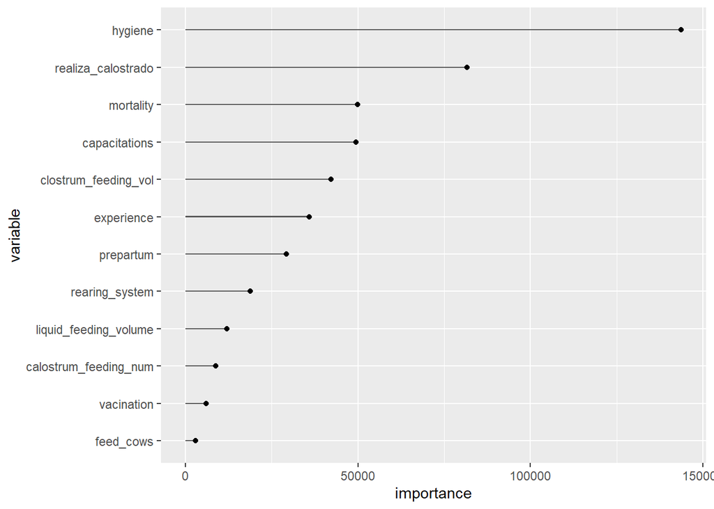